# Exploring Gapminder data

R User

2022-04-26

# 1 The data

In this report, we explore data from [*Gapminder*](https://www.gapminder.org/). More specifically, we use an excerpt from these data that is included in the [`gapminder` package for `R`](https://github.com/jennybc/gapminder). The data contains information about life expectancy, population, and GDP per capita for 142 countries from 5 different continents, spanning the time from 1952 to 2007.

# 2 Analyses

For our exploration, we will focus on data from the year 2007.

## 2.1 Life expectancy

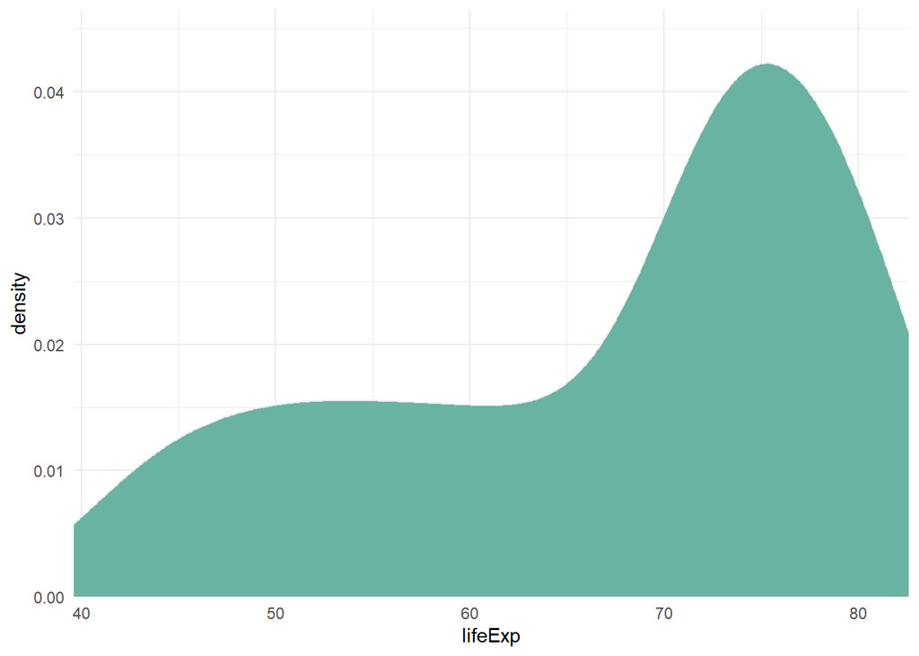

Distribution of life expectancy in 2007

```r
gap_2007 %>%
  ggplot(aes(x = lifeExp)) +
  geom_density(fill="#69b3a2",
               color="#e9ecef") +
  scale_y_continuous(expand=expansion(mult=c(0,0.1))) +
  scale_x_continuous(expand=expansion(mult=c(0,0))) +
  theme_minimal()
```

```r
gap_2007 %>%
  select(country, continent,lifeExp) %>%
  arrange(-lifeExp) %>%
  head(10) %>%
  knitr::kable(caption = "10 countries with the highest life expectancy in 2007")
```

10 countries with the highest life expectancy in 2007

| country | continent | lifeExp |
| --- | --- | --- |
| Japan | Asia | 83 |
| Hong Kong, China | Asia | 82 |
| Iceland | Europe | 82 |
| Switzerland | Europe | 82 |
| Australia | Oceania | 81 |
| Spain | Europe | 81 |
| Sweden | Europe | 81 |
| Israel | Asia | 81 |
| France | Europe | 81 |
| Canada | Americas | 81 |

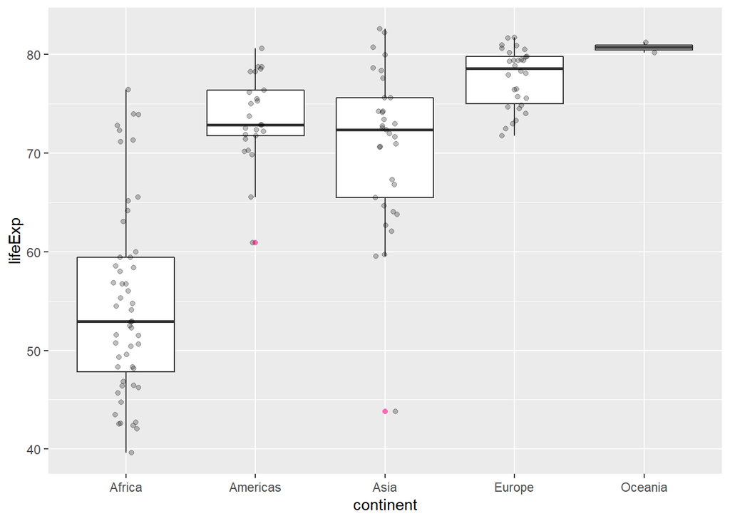

Differences between continents in average life expectancy in 2007

```r
gap_2007 %>%
  ggplot(aes(x = continent, y = lifeExp)) +
  geom_boxplot(outlier.colour = "hotpink") +
  geom_jitter(position = position_jitter(width = 0.1, height = 0),
              alpha = 0.25)
```

## 2.2 GDP per capita

As we can see, GDP per capita is heavily right-skewed.

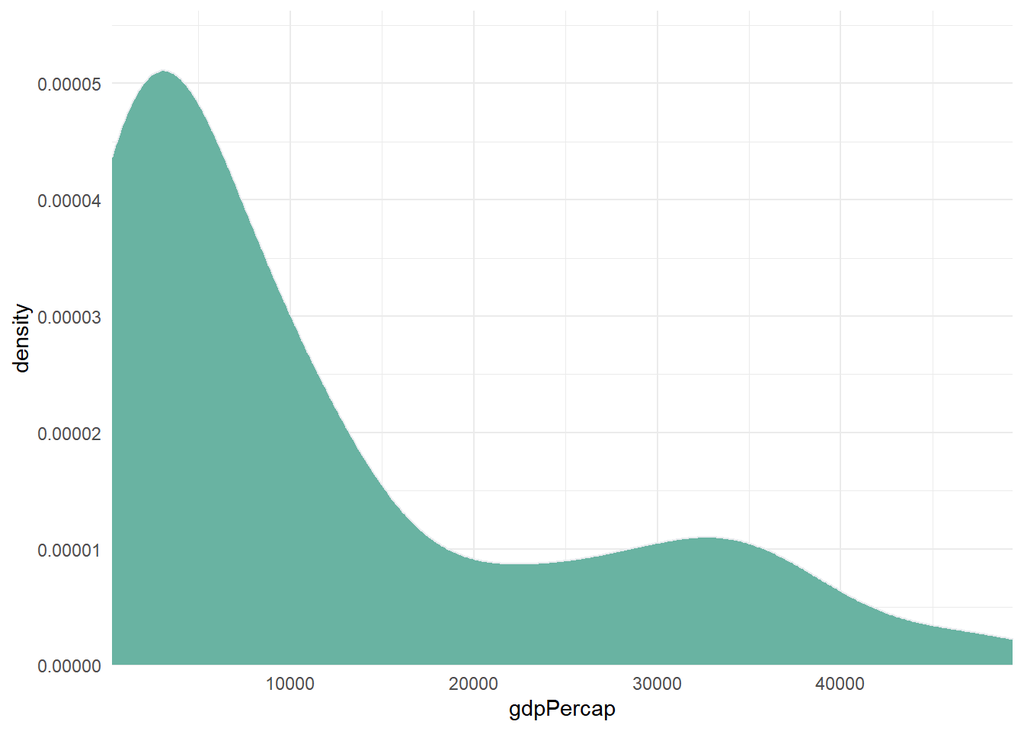

Distribution of GPD per capita in 2007

```r
gap_2007 %>%
  ggplot(aes(x = gdpPercap)) +
  geom_density(fill="#69b3a2",
               color="#e9ecef") +
  scale_y_continuous(expand=expansion(mult=c(0,0.1))) +
  scale_x_continuous(expand=expansion(mult=c(0,0))) +
  theme_minimal()
```

```r
gap_2007 %>%
  select(country, continent,gdpPercap) %>%
  arrange(-gdpPercap) %>%
  head(10) %>%
  knitr::kable(caption = "10 countries with the highest GDP per capita in 2007")
```

10 countries with the highest GDP per capita in 2007

| country | continent | gdpPercap |
| --- | --- | --- |
| Norway | Europe | 49357 |
| Kuwait | Asia | 47307 |
| Singapore | Asia | 47143 |
| United States | Americas | 42952 |
| Ireland | Europe | 40676 |
| Hong Kong, China | Asia | 39725 |
| Switzerland | Europe | 37506 |
| Netherlands | Europe | 36798 |
| Canada | Americas | 36319 |
| Iceland | Europe | 36181 |

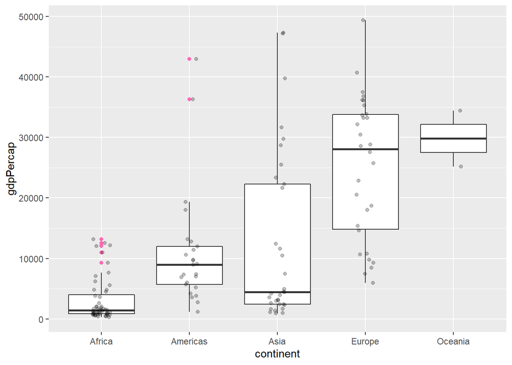

Differences between continents in GDP per capita in 2007

```r
gap_2007 %>%
  ggplot(aes(x = continent, y = gdpPercap)) +
  geom_boxplot(outlier.colour = "hotpink") +
  geom_jitter(position = position_jitter(width = 0.1, height = 0),
              alpha = 0.25)
```

## 2.3 Relationship between life expectancy and GDP per capita

We employ a bubble plot as made popular by the [TED talk by Hans Rosling](https://www.ted.com/talks/hans_rosling_the_best_stats_you_ve_ever_seen) to visualize the relationship between GDP per capita and life expectancy in 2007. The plot also includes visual information about the continent on which a country is located as well as its population size.

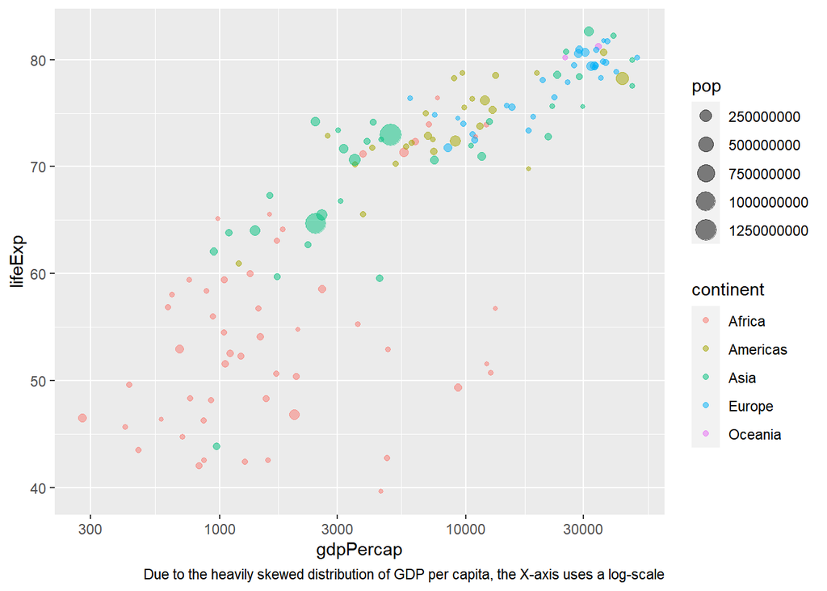

```r
gap_2007 %>%
ggplot(aes(x = gdpPercap, y = lifeExp)) +
  geom_point(aes(size = pop,
                 color = continent),
             alpha = .5) +
  scale_x_log10() +
  labs(caption = "Due to the heavily skewed distribution of GDP per capita, the X-axis uses a log-scale")
```

# 3 Reproducibility information